# The relationship between early phonological and lexical development

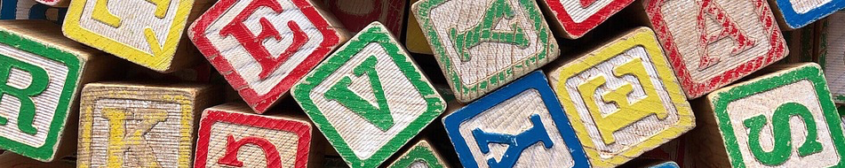

## Summer School of Linguistics, Kroměříž, Czech Republic

### [Mits Ota](http://lel.ppls.ed.ac.uk/~mits) (University of Edinburgh)

This is a website for [my lectures on early phonological and lexical development](https://www.lingvistika.cz/summer-school-of-linguistics/ssol-2019/lecture-abstracts-ssol-2019#h.p_Vetm-iBsSaOb) given at the [Summer School of Linguistics](https://www.lingvistika.cz/) on 9-12 August 2019. Scroll down to access lecture slides and links to references mentioned in the lectures. If you have any questions, please email me at mits@ling.ed.ac.uk.

## Background readings

The following articles provide some general background for the main issues I will be discussing in the lecture.

- Stoel-Gammon, C. (2011). [Relationships between lexical and phonological development in young children](https://doi.org/10.1017/S0305000910000425). *Journal of Child Language, 38*, 1-34.
- Swingley, D. (2009). [Contributions of word learning to language development](https://doi.org/10.1098/rstb.2009.0107). *Philosophical Transactions of the Royal Society B*, 364.
- Vihman, M. M. (2017). [Learning words and learning sounds: Advances in language development](https://doi.org/10.1111/bjop.12207). *British Journal of Psychology, 108*, 1-27.

## Slides

- Lecture 1: Can sound categories be learned without words?
- Lecture 2: How do phonological representations of words develop?
- Lecture 3: How do lexical factors affect phonological development?
- Lecture 4: How does phonology affect word learning?

## Useful online resources

- [CHILDES](https://childes.talkbank.org/): Corpus data of early langauge production.
- [MetaLab’s early language data](http://metalab.stanford.edu/domain/early_language.html): Meta analyses of effects in early language development
- [Phonotactic probability and neighborhood density calculator](http://www.people.ku.edu/~mvitevit/PhonoProbHome.html): Include child corpus data for American English.
- [Wordbank](http://wordbank.stanford.edu/): An open database of children’s vocabulary development.

## References

Here are most, if not all, of the references mentioned in the lectures. Sources available online are linked to the title. Please let me know if you need information for other studies that appear on the slides.

- Ambridge, B., & Lieven, E. V. (2011). [*Child language acquisition: Contrasting theoretical approaches*](https://doi.org/10.1017/CBO9780511975073). Cambridge University Press.
- Bergelson, E., & Swingley, D. (2015). [Early word comprehension in infants: Replication and extension](https://doi.org/10.1080/15475441.2014.979387). *Language Learning and Development, 11*, 369-380.
- Berko Gleason, J., Perlmann, R. Y., Ely, R., & Evans, D. W. ( 1994). The baby talk register: Parents’ use of diminutives. In J. L. Sokolov & C. E. Snow (Eds.), *Handbook of research in language using CHILDES* (pp. 50– 76). Hillsdale, NJ: Lawrence Erlbaum.
- Bion, R. A., Miyazawa, K., Kikuchi, H., & Mazuka, R. (2013). [Learning phonemic vowel length from naturalistic recordings of Japanese infant-directed speech](https://doi.org/10.1371/journal.pone.0051594). *PloS One, 8*, e51594.
- Bortfeld, H., Morgan, J. L., Golinkoff, R. M., & Rathbun, K. (2005). [Mommy and me: Familiar names help launch babies into speech-stream segmentation](https://doi.org/10.1111/j.0956-7976.2005.01531.x). *Psychological Science, 16*, 298-304.
- Brent, M. R., & Siskind, J. M. (2001). The role of exposure to isolated words in early vocabulary development. *Cognition, 81*, B33-B44.
- Caselli, M. C., Bates, E., Casadio, P., Fenson, J., Fenson, L., Sanderl, L., & Weir, J. (1995). A cross-linguistic study of early lexical development. *Cognitive Development, 10*, 159-199.
- Charles-Luce, J., & Luce, P. A. (1995). [An examination of similarity neighbourhoods in young children’s receptive vocabularies](https://doi.org/10.1017/S0305000900010023). *Journal of Child Language, 22*, 727-735.
- Cristià, A., McGuire, G. L., Seidl, A., & Francis, A. L. (2011). [Effects of the distribution of acoustic cues on infants’ perception of sibilants](https://doi.org/10.1016/j.wocn.2011.02.004). *Journal of Phonetics, 39*, 388-402.
- Cutler, A., & Carter, D. M. (1987). The predominance of strong initial syllables in the English vocabulary. *Computer Speech & Language, 2*, 133-142.
- DePaolis, R. A., Vihman, M. M., & Keren-Portnoy, T. (2011). [Do production patterns influence the processing of speech in prelinguistic infants?](https://doi.org/10.1016/j.infbeh.2011.06.005). *Infant Behavior and Development, 34*, 590-601.
- Dingemanse, M., Blasi, D. E., Lupyan, G., Christiansen, M. H., & Monaghan, P. (2015). [Arbitrariness, iconicity, and systematicity in language](https://doi.org/10.1016/j.tics.2015.07.013). *Trends in Cognitive Sciences, 19*, 603-615.
- Echols, C. H., Crowhurst, M. J., & Childers, J. B. (1997). [The perception of rhythmic units in speech by infants and adults](https://doi.org/10.1006/jmla.1996.2483). *Journal of Memory and Language, 36*, 202-225.
- Edwards, J., Beckman, M. E., & Munson, B. (2004). The interaction between vocabulary size and phonotactic probability effects on children’s production accuracy and fluency in nonword repetition. *Journal of Speech, Language, and Hearing Research, 47*, 421-436.
- Eimas, P. D., Siqueland, E. R., Jusczyk, P., & Vigorito, J. (1971). [Speech perception in infants](https://doi.org/10.1126/science.171.3968.303). *Science, 171*, 303-306.
- Endress, A. D., Nespor, M., & Mehler, J. (2009). [Perceptual and memory constraints on language acquisition](https://doi.org/10.1016/j.tics.2009.05.005). *Trends in Cognitive Sciences, 13*, 348-353.
- Feldman, N. H., Griffiths, T. L., Goldwater, S., & Morgan, J. L. (2013). [A role for the developing lexicon in phonetic category acquisition](https://doi.org/10.1037/a0034245). *Psychological Review, 120*, 751-778.
- Feldman, N. H., Myers, E. B., White, K. S., Griffiths, T. L., & Morgan, J. L. (2013). [Word-level information influences phonetic learning in adults and infants](https://doi.org/10.1016/j.cognition.2013.02.007). *Cognition, 127*, 427-438.
- Fennell, C. T., & Werker, J. F. (2003). [Early word learners’ ability to access phonetic detail in well-known words](https://doi.org/10.1177/00238309030460020901). *Language and Speech, 46*, 245-264.
- Fennell, C. T., & Waxman, S. R. (2010). [What paradox? Referential cues allow for infant use of phonetic detail in word learning](https://doi.org/10.1111/j.1467-8624.2010.01479.x). *Child Development, 81*, 1376-1383.
- Ferguson, C. A. (1964). [Baby talk in six languages](https://doi.org/10.1525/aa.1964.66.suppl_3.02a00060). *American aAnthropologist, 66*, 103-114.
- Ferguson, C. A. (1977). Baby talk as a simplified register. In C. E. Snow & C. A. Ferguson (Eds.), *Talking to children* (pp. 209-235). Cambridge: Cambridge University Press.
- Ferguson, C. A., & Farwell, C. B. (1975). [Words and sounds in early language acquisition](https://doi.org/10.2307/412864). *Language, 51*, 419-439.
- Frank, M. C., Braginsky, M., Yurovsky, D., & Marchman, V. A. (2017). [Wordbank: An open repository for developmental vocabulary data](https://doi.org/10.1017/S0305000916000209). *Journal of Child Language, 44*, 677-694. Webpage: http://wordbank.stanford.edu/
- Garlock, V. M., Walley, A. C., & Metsala, J. L. (2001). [Age-of-acquisition, word frequency, and neighborhood density effects on spoken word recognition by children and adults](https://doi.org/10.1006/jmla.2000.2784). *Journal of Memory and Language, 45*, 468-492.
- Gervain, J., Macagno, F., Cogoi, S., Peña, M., & Mehler, J. (2008). [The neonate brain detects speech structure](https://doi.org/10.1073/pnas.0806530105). *Proceedings of the National Academy of Sciences, 105*, 14222-14227.
- Gervain, J., Berent, I., & Werker, J. F. (2012). [Binding at birth: The newborn brain detects identity relations and sequential position in speech](https://doi.org/10.1162/jocn_a_00157). *Journal of Cognitive Neuroscience, 24*, 564-574.
- Gonzalez-Gomez, N., Hayashi, A., Tsuji, S., Mazuka, R., & Nazzi, T. (2014). [The role of the input on the development of the LC bias: A crosslinguistic comparison](https://doi.org/10.1016/j.cognition.2014.04.004). *Cognition, 132*, 301-311.
- Greenberg, J. H. (1950). [The patterning of root morphemes in Semitic](https://doi.org/10.1080/00437956.1950.11659378). *Word, 6*, 162-181.
- Guenther, F. H., & Gjaja, M. N. (1996). [The perceptual magnet effect as an emergent property of neural map formation](https://doi.org/10.1121/1.416296). *The Journal of the Acoustical Society of America, 100*, 1111-1121.
- Hocket, C. (1958). *A course in modern linguistics*. New York: MacMillan.
- Imai, M., & Kita, S. (2014). [The sound symbolism bootstrapping hypothesis for language acquisition and language evolution](https://doi.org/10.1098/rstb.2013.0298). *Philosophical Transactions of the Royal Society B: Biological Sciences, 369*, 20130298.
- Jusczyk, P. W. (1997). *The discovery of spoken language*. Cambridge, MA: MIT press.
- Jusczyk, P. W., & Aslin, R. N. (1995). [Infants′ detection of the sound patterns of words in fluent speech](https://doi.org/10.1006/cogp.1995.1010). *Cognitive Psychology, 29*, 1-23.
- Jusczyk, P. W., Goodman, M. B., & Baumann, A. (1999). [Nine-month-olds’ attention to sound similarities in syllables](https://doi.org/10.1006/jmla.1998.2605). *Journal of Memory and Language, 40*, 62-82.
- Jusczyk, P. W., Houston, D. M., & Newsome, M. (1999). [The beginnings of word segmentation in English-learning infants](https://doi.org/10.1006/cogp.1999.0716). *Cognitive Psychology, 39*, 159-207.
- Jusczyk, P. W., Luce, P. A., & Charles-Luce, J. (1994). [Infants’ sensitivity to phonotactic patterns in the native language](http://dx.doi.org/10.1006/jmla.1994.1030). *Journal of Memory and Language, 33*, 630.
- Kelly, M. H., & Martin, S. (1994). Domain-general abilities applied to domain-specific tasks: Sensitivity to probabilities in perception, cognition, and language. *Lingua, 92*, 105-140.
- Kempe, V., Brooks, P. J., & Gillis, S. (2005). [Diminutives in child-directed speech supplement metric with distributional word segmentation cues](https://doi.org/10.3758/BF03196360). *Psychonomic Bulletin & Review, 12*, 145-151.
- Kempe, V., Brooks, P. J., Gillis, S., & Samson, G. (2007). [Diminutives facilitate word segmentation in natural speech: Cross-linguistic evidence](https://doi.org/10.3758/BF03193313). *Memory & cCognition, 35*, 762-773.
- Kuhl, P. K., Andruski, J. E., Chistovich, I. A., Chistovich, L. A., Kozhevnikova, E. V., Ryskina, V. L., Stolyarova, E. I., Sundberg, U., & Lacerda, F. (1997). [Cross-language analysis of phonetic units in language addressed to infants](https://doi.org/10.1126/science.277.5326.684). *Science, 277*, 684-686.
- Kuhl, P. K., Stevens, E., Hayashi, A., Deguchi, T., Kiritani, S., & Iverson, P. (2006). [Infants show a facilitation effect for native language phonetic perception between 6 and 12 months](https://doi.org/10.1111/j.1467-7687.2006.00468.x). *Developmental Science, 9*, F13-F21.
- Laing, C. E. ( 2014). [A phonological analysis of onomatopoeia in early word production](https://doi.org/10.1177/0142723714550110). *First Language, 34*, 387– 405.
- Leonard, L. B., & Ritterman, S. I. (1971). [Articulation of /s/ as a function of cluster and word frequency of occurrence](https://doi.org/10.1044/jshr.1403.476). *Journal of Speech and Hearing Research, 14*, 476-485.
- Lleó, C., & Demuth, K. (1999). Prosodic constraints on the emergence of grammatical morphemes: Crosslinguistic evidence from Germanic and Romance languages. In Proceedings of the 23rd Annual Boston University Conference on Language Development (Vol. 2, pp. 407-418).
- Logan, J. S. (1992). *A computational analysis of young children’s lexicons*. Technical report. Indiana University.
- MacKain, K. S. (1982). [Assessing the role of experience on infants’ speech discrimination](https://doi.org/10.1017/S030500090000489X). *Journal of Child Language, 9*, 527-542.
- MacNeilage, P. F. (1998). [The frame/content theory of evolution of speech production](https://doi.org/10.1017/S0140525X98001265). *Behavioral and Brain Sciences, 21*, 499-511.
- MacNeilage, P. F., Davis, B. L., Kinney, A., & Matyear, C. L. (1999). [Origin of serial-output complexity in speech](https://doi.org/10.1111/1467-9280.00187). *Psychological Science, 10*, 459-460.
- MacNeilage, P. F., Davis, B. L., Kinney, A., & Matyear, C. L. (2000). [The motor core of speech: A comparison of serial organization patterns in infants and languages](https://doi.org/10.1111/1467-8624.00129). Child Development, 71(1), 153-163.
- MacNeilage, P. F., & Davis, B. L. (2000). [On the origin of internal structure of word forms](https://doi.org/10.1126/science.288.5465.527). *Science, 288*, 527-531.
- Majorano, M., Vihman, M. M., & DePaolis, R. A. (2014). [The relationship between infants’ production experience and their processing of speech](https://doi.org/10.1080/15475441.2013.829740). *Language Learning and Development, 10*, 179-204.
- Marslen-Wilson, W. D. (1987). Functional parallelism in spoken word-recognition. *Cognition, 25*, 71-102.
- Massaro, D. W., & Perlman, M. (2017). [Quantifying iconicity’s contribution during language acquisition: Implications for vocabulary learning](https://doi.org/10.3389/fcomm.2017.00004). *Frontiers in Communication, 2*, 4.
- Mattys, S. L., Jusczyk, P. W., Luce, P. A., & Morgan, J. L. (1999). [Phonotactic and prosodic effects on word segmentation in infants](https://doi.org/10.1006/cogp.1999.0721). *Cognitive Psychology, 38*, 465-494.
- Maurer, D., Pathman, T., & Mondloch, C. J. (2006). [The shape of boubas: Sound–shape correspondences in toddlers and adults](https://doi.org/10.1111/j.1467-7687.2006.00495.x). *Developmental Science, 9*, 316-322.
- Maye, J., Werker, J. F., & Gerken, L. (2002). Infant sensitivity to distributional information can affect phonetic discrimination. *Cognition, 82*, B101-B111.
- Maye, J., Weiss, D. J., & Aslin, R. N. (2008). [Statistical phonetic learning in infants: Facilitation and feature generalization](https://doi.org/10.1111/j.1467-7687.2007.00653.x). *Developmental Science, 11*, 122-134.
- McCarthy, J. J. (1986). [OCP effects: Gemination and antigemination](https://www.jstor.org/stable/4178486). *Linguistic Inquiry, 17*, 207-263.
- Metsala, J. L., & Walley, A. C. (1998). Spoken vocabulary growth and the segmental restructuring of lexical representations: Precursors to phonemic awareness and early reading ability. In J.L. Metsala & L.C. Ehri (Eds.), *Word recognition in beginning literacy* (pp. 89–120). Mahwah, NJ: Erlbaum.
- Monaghan, P., & Zuidema, W. (2015). [General purpose cognitive processing constraints and phonotactic properties of the vocabulary](https://pure.mpg.de/rest/items/item_2351030/component/file_2351029/content#page=24). Paper presented at the Workshop on the Evolution and Phonetic Capabilities: Causes, Constraints and Consequences.
- Ota, M. (2006). [Input frequency and word truncation in child Japanese: Structural and lexical effects](https://doi.org/10.1177/00238309060490020601). *Language and Speech, 49*, 261-294.
- Ota, M., & Green, S. J. (2013). [Input frequency and lexical variability in phonological development: A survival analysis of word-initial cluster production](https://doi.org/10.1017/S0305000912000074). *Journal of Child Language, 40*, 539-566.
- Ota, M., & Skarabela, B. (2016). [Reduplicated words are easier to learn](https://doi.org/10.1080/15475441.2016.1165100). *Language Learning and Development, 12*, 380-397
- Ota, M., & Skarabela, B. (2018). [Reduplication facilitates early word segmentation](https://doi.org/10.1017/S0305000916000660). *Journal of Child Language, 45*, 204-218.
- Ota, M., Davies‐Jenkins, N., & Skarabela, B. (2018). [Why *choo‐choo* is better than *train*: The role of register‐specific words in early vocabulary growth](https://doi.org/10.1111/cogs.12628). *Cognitive Science, 42*, 1974-1999.
- Saffran, J. R., Aslin, R. N., & Newport, E. L. (1996). [Statistical learning by 8-month-old infants](https://doi.org/10.1126/science.274.5294.1926). *Science, 274*, 1926-1928.
- Schwartz, R. G., & Leonard, L. B. (1982). [Do children pick and choose? An examination of phonological selection and avoidance in early lexical acquisition](https://doi.org/10.1017/S0305000900004748). *Journal of Child Language, 9*, 319-336.
- Skarabela, B., Ota, M., Fazekas, J., & Wihlborg, L. (2015). [Do baby‐talk words reflect biomechanical constraints on speech production](https://www.internationalphoneticassociation.org/icphs-proceedings/ICPhS2015/Papers/ICPHS1023.pdf)? In The Scottish Consortium of ICPhD (Ed.), *Proceedings of the 18th International Congress of Phonetic Sciences*. Glasgow, UK: University of Glasgow.
- Sosa, A. V., & Stoel-Gammon, C. (2006). [Patterns of intra-word phonological variability during the second year of life](https://doi.org/10.1017/S0305000905007166). *Journal of Child Language, 33*, 31-50.
- Stager, C. L., & Werker, J. F. (1997). [Infants listen for more phonetic detail in speech perception than in word-learning tasks](https://doi.org/10.1038/41102). *Nature, 388*, 381.
- Starling, G. (2018). [Vowel production in infant-directed speech: An assessment of hyperarticulation and distributional learning](https://www.era.lib.ed.ac.uk/handle/1842/35676). Unpublished doctoral dissertation, University of Edinburgh.
- Stoel-Gammon, C. (1998). Sounds and words in early language acquisition: The relationship between lexical and phonological development. In R. Paul (Ed.), *Exploring the speech-language connection* (pp. 25–52).Baltimore, MD: Brookes.
- Stoel-Gammon, C., & Cooper, J. A. (1984). [Patterns of early lexical and phonological development](https://doi.org/10.1017/S0305000900005766). *Journal of Child language, 11*, 247-271.
- Swingley, D. (2003). [Phonetic detail in the developing lexicon](https://doi.org/10.1177/00238309030460021001). *Language and Speech, 46*, 265-294.
- Swingley, D. (2005). [11‐month‐olds’ knowledge of how familiar words sound](https://doi.org/10.1111/j.1467-7687.2005.00432.x). *Developmental Science, 8*, 432-443.
- Swingley, D. (2007). [Lexical exposure and word-form encoding in 1.5-year-olds](https://doi.org/10.1037/0012-1649.43.2.454). *Developmental Psychology, 43*, 454.
- Swingley, D., & Alarcon, C. (2018). [Lexical learning may contribute to phonetic learning in infants: A corpus analysis of maternal Spanish](https://doi.org/10.1111/cogs.12620). *Cognitive Science, 42*, 1618-1641.
- Swingley, D., & Aslin, R. N. (2002). [Lexical neighborhoods and the word-form representations of 14-month-olds](https://doi.org/10.1111/1467-9280.00485). *Psychological Science, 13*, 480-484.
- Tsuji, S., & Cristia, A. (2014). [Perceptual attunement in vowels: A meta‐analysis](https://doi.org/10.1002/dev.21179). *Developmental Psychobiology, 56*, 179-191.
- Vallabha, G. K., McClelland, J. L., Pons, F., Werker, J. F., & Amano, S. (2007). [Unsupervised learning of vowel categories from infant-directed speech](https://doi.org/10.1073/pnas.0705369104). *Proceedings of the National Academy of Sciences, 104*, 13273-13278.
- Vihman, M. M. (1996). Phonological development: The origins of language in the child. Oxford: Blackwell Publishing.
- Vihman, M. M., & McCune, L. (1994). [When is a word a word?](https://doi.org/10.1017/S0305000900009442). *Journal of Child Language, 21*, 517-542.
- Vihman, M. M., Nakai, S., DePaolis, R. A., & Hallé, P. (2004). [The role of accentual pattern in early lexical representation](https://doi.org/10.1016/j.jml.2003.11.004). *Journal of Memory and Language, 50*, 336-353.
- Werker, J. F., & Tees, R. C. (1984). Cross-language speech perception: Evidence for perceptual reorganization during the first year of life. *Infant Behavior and Development, 7*, 49-63.
- Yoshida, K. A., Fennell, C. T., Swingley, D., & Werker, J. F. (2009). [Fourteen‐month‐old infants learn similar‐sounding words](https://doi.org/10.1111/j.1467-7687.2008.00789.x). *Developmental Science, 12*, 412-418.
- Zamuner, T. S., Gerken, L., & Hammond, M. (2004). [Phonotactic probabilities in young children’s speech production](https://doi.org/10.1017/S0305000904006233). *Journal of Child Language, 31*, 515-536.
- Zamuner, T. S., Gerken, L., & Hammond, M. (2005). [The acquisition of phonology based on input: A closer look at the relation of cross-linguistic and child language data](https://doi.org/10.1016/j.lingua.2004.06.005). *Lingua, 115*, 1403-1426.